# Results

# Univariate ANOVA table summary

| Model | Dataset | Trait | Chisq | P |
| --- | --- | --- | --- | --- |
| Model 1: Mainland/Island | Mericarp | Length | 14.101 | 0.000 |
|  |  | Year Length | 8.619 | 0.003 |
|  |  | Width | 12.438 | 0.000 |
|  |  | Year Width | 8.160 | 0.004 |
|  |  | Depth | 52.334 | 0.000 |
|  |  | Year Depth | 19.542 | 0.000 |
|  |  | Tip Distance | 6.090 | 0.014 |
|  |  | Year Tip Distance | 0.028 | 0.868 |
|  |  | Lower Spines | 76.744 | 0.000 |
| Model 1: Mainland/Island | Flower | Petal Length | 1.077 | 0.299 |
|  |  | Year Petal Length | 15.899 | 0.000 |
| Model 1: Mainland/Island | Leaf | Leaf Length | 21.862 | 0.000 |
|  |  | Year Leaf Length | 6.502 | 0.011 |
|  |  | Leaflet Length | 4.865 | 0.027 |
|  |  | Year Leaflet Length | 8.693 | 0.003 |
|  |  | Leaf Number | 39.619 | 0.000 |
| Model 2: Galapagos/Other Islands | Flower | Petal Length | 156.398 | 0.000 |
|  |  | Year Petal Length | 10.133 | 0.001 |
| Model 2: Galapagos/Other Islands | Leaf | Leaf Length | 20.397 | 0.000 |
|  |  | Year Leaf Length | 0.573 | 0.449 |
|  |  | Leaflet Length | 17.206 | 0.000 |
|  |  | Year Leaflet Length | 0.882 | 0.348 |
|  |  | Leaf Number | 1.864 | 0.172 |
| Model 3: Finch Beak Presence/Absence | Mericarp | Length | 3.018 | 0.082 |
|  |  | Year Length | 0.157 | 0.692 |
|  |  | Width | 0.277 | 0.599 |
|  |  | Year Width | 0.963 | 0.326 |
|  |  | Depth | 0.795 | 0.373 |
|  |  | Year Depth | 2.468 | 0.116 |
|  |  | Tip Distance | 1.313 | 0.252 |
|  |  | Year Tip Distance | 0.005 | 0.944 |
|  |  | Lower Spines | 2.487 | 0.115 |
| Model 3: Finch Beak Presence/Absence | Flower | Petal Length | 0.346 | 0.556 |
|  |  | Year Petal Length | 6.720 | 0.010 |
| Model 3: Finch Beak: Presence/Absence | Leaf | Leaf Length | 1.879 | 0.170 |
|  |  | Year Leaf Length | 12.856 | 0.000 |
|  |  | Leaflet Length | 2.028 | 0.154 |
|  |  | Year Leaflet Length | 3.709 | 0.054 |
|  |  | Leaf Number | 0.113 | 0.737 |
|  |  | Year Leaf Number | 11.986 | 0.001 |

# Multivariate analysis: trait ~ group + condition(year)

## Model 1: Mainland/Island

### Mericarp

We observed that mericarps from islands and mainlands populations differed in size and number of spines. Mericarps on islands are larger than mericarps on the mainland with depth being the variable that contributes more to the variation of mericarp size. For spines, the presence of lower spines was more related to mainland populations than to island populations and was the variable that contribute to most of the variation between the two groups.

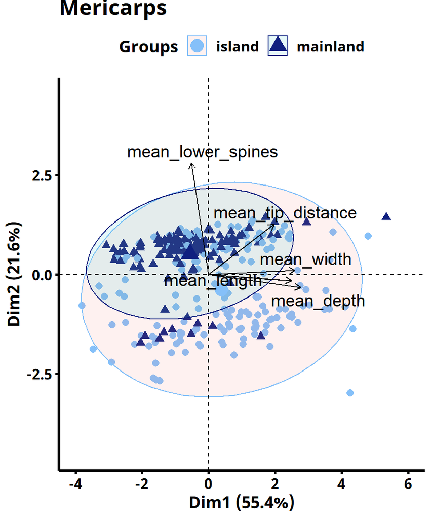

|  | Df | Variance | F | Pr(>F) |
| --- | --- | --- | --- | --- |
| mainland_island | 1 | 0.2606884 | 255.7926 | 0.001 |
| Residual | 4626 | 4.7145399 | NA | NA |

### Leaf

Leaves are larger on islands than in the mainland. This size difference also contributes to the number of leaflets present, with island populations habving more. This trait is the main difference between the two groups.

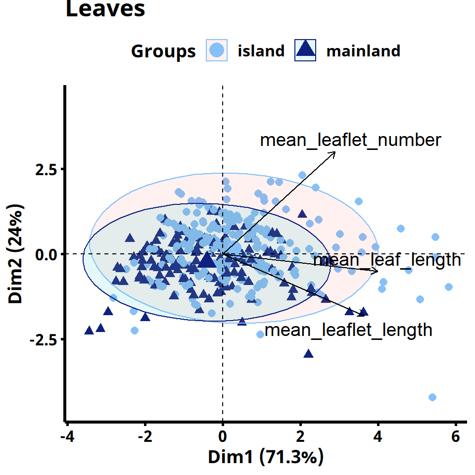

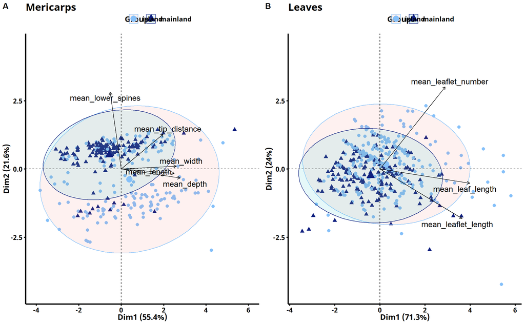